# Repeated Measures: Covariance Structures in ASReml

Dr. Samuel B Fernandes

2026-01-01

## Like before, it starts with your questions.

*Define your research questions/hypothesis.*

We need a null hypothesis for each question, for example:

Does irrigation affect the yield of different cultivars differently?

$H_0:i_1cv_1=i_2cv_2= ...=i_ncv_n=0$  
$H_a:$ at least one combination of cultivar and irrication will yield differently.

## Designing an experiment to answer your questions

First of all, I will load all packages I know will used downstream.

```r
library(tidyverse)
library(ggpubr)
library(rstatix)
library(desplot)
library(asremlPlus)
library(asreml)
```

What design should I choose?

- Do I have homogeneous experimental units within each block?
- Can all factors in my experiment be just as easily randomized?

You can use FielD. Lets create a split plot design and save it as “Split-Plot_2025-04-04.csv”.

```r
library(FielDHub)
run_app()
```

## It is time for analysis

After running the experiment and collecting data with the hightest quality possible, Loading the data and creating a “fake” split-plot with the same response variable to illustrate the split-plot analysis.

```r
alfaRCBD <- read.table("ALFALFA.txt", header = TRUE, na.string = "*")
alfaSPLIT <- read_csv("Split-Plot_2025-04-04.csv") |>
    mutate(resp = alfaRCBD$Resp) |>
    rename(irrigation = "WHOLE_PLOT", cv = "SUB_PLOT", col = "COLUMN", block = "REP") |>
    select(-ID, -LOCATION, -TRT_COMB)
colnames(alfaSPLIT) <- tolower(colnames(alfaSPLIT))
```

Creating factors

```r
alfaRCBD <- transform(alfaRCBD,
    cv = as.factor(Variety),
    b = factor(Block)
)

alfaSPLIT <- transform(alfaSPLIT,
    cv = factor(cv),
    block = factor(block),
    irrigation = factor(irrigation)
)
```

## EDA - explatoraty data analysis

Understanding the experiment

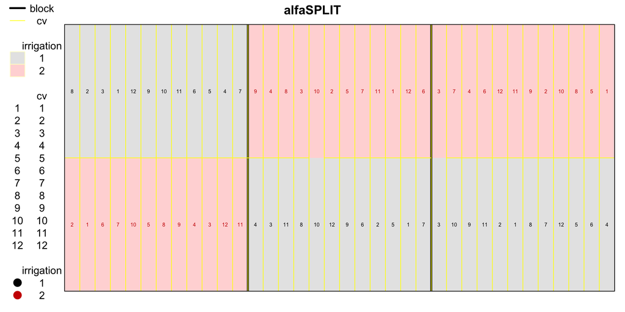

```r
desplot(
    alfaSPLIT,
    irrigation ~ row + col,
    col = irrigation,
    cex = .5,
    num = cv,
    out1 = block,
    out2 = cv
)
```

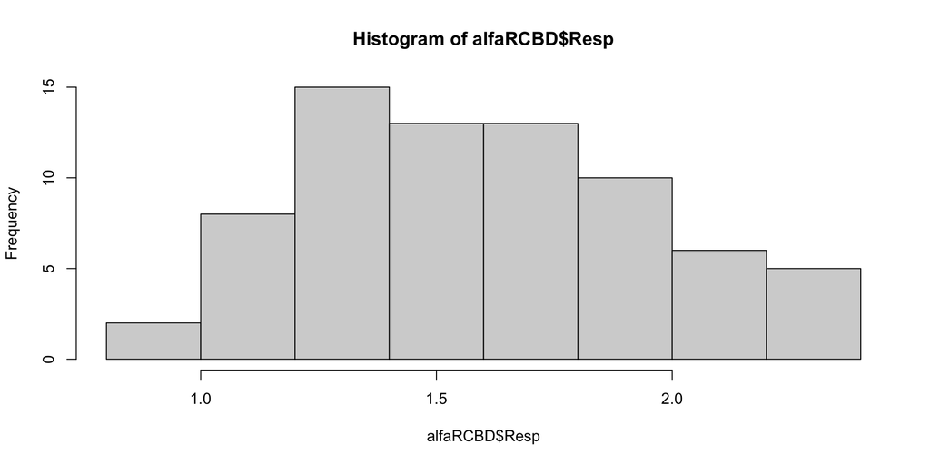

```r
hist(alfaRCBD$Resp)
```

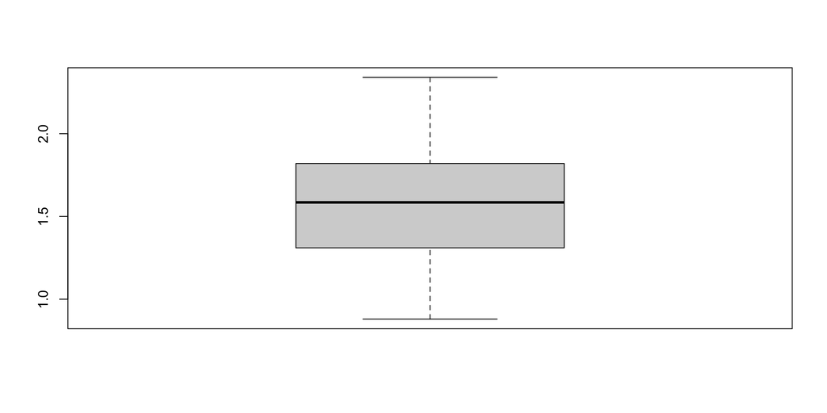

```r
boxplot(alfaRCBD$Resp)
```

```r
table(alfaRCBD$Variety, alfaRCBD$Block)
```

```
#>
#>     1 2 3 4 5 6
#>   A 1 1 1 1 1 1
#>   B 1 1 1 1 1 1
#>   C 1 1 1 1 1 1
#>   D 1 1 1 1 1 1
#>   E 1 1 1 1 1 1
#>   F 1 1 1 1 1 1
#>   G 1 1 1 1 1 1
#>   H 1 1 1 1 1 1
#>   I 1 1 1 1 1 1
#>   J 1 1 1 1 1 1
#>   K 1 1 1 1 1 1
#>   L 1 1 1 1 1 1
```

# Mixed effects model

## Analysis using ASReml - RCBD

A mixed model with cv as a random effect by all the ANOVA assumptions still hold.

```r
alfaRCBD <- alfaRCBD %>%
    arrange(cv, b)

rcbd1 <- asreml(
    fixed = Resp ~ b,
    random = ~cv,
    # residual=<error structure>,
    data = alfaRCBD
)
```

```
#> ASReml Version 4.2 30/03/2026 10:33:43
#>           LogLik        Sigma2     DF     wall
#>  1      48.73447    0.06197422     66   10:33:43
#>  2      50.02113    0.05731910     66   10:33:43
#>  3      51.15010    0.05255230     66   10:33:43
#>  4      51.69752    0.04874910     66   10:33:43
#>  5      51.73661    0.04775121     66   10:33:43
#>  6      51.73696    0.04765360     66   10:33:43
```

## Diagnostics

```r
par(mfrow = c(2, 2))
plot(rcbd1)
```

```r
par(mfrow = c(1, 1))
```

[figure not shown]

## Dropping the assumtions

Dropping the assumtion of `homogeneity` of variances (“diag()” estructure) across cultivars.

```r
rcbd2 <- asreml(
    fixed = Resp ~ b,
    random = ~cv,
    residual = ~ diag(cv):id(b),
    data = alfaRCBD
)
```

```
#> ASReml Version 4.2 30/03/2026 10:33:43
#>           LogLik        Sigma2     DF     wall
#>  1      48.02611           1.0     66   10:33:43  (  1 restrained)
#>  2      52.37703           1.0     66   10:33:43  (  1 restrained)
#>  3      52.85416           1.0     66   10:33:43  (  1 restrained)
#>  4      57.36453           1.0     66   10:33:43  (  1 restrained)
#>  5      58.08428           1.0     66   10:33:43  (  1 restrained)
#>  6      58.15785           1.0     66   10:33:43
#>  7      58.16005           1.0     66   10:33:43
```

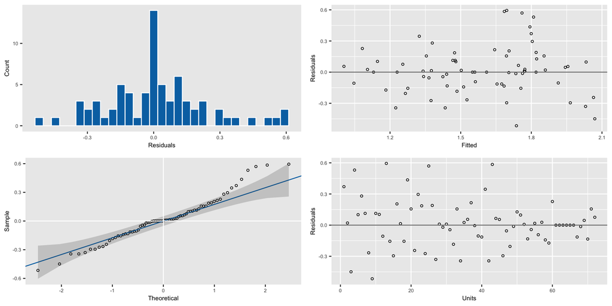

```r
plot(rcbd2)
```

## Dropping the assumtions

Dropping the assumtion of `independent` residuals (“ar1()” estructure) across cultivars.

```r
rcbd3 <- asreml(
    fixed = Resp ~ b,
    random = ~cv,
    residual = ~ ar1(cv):id(b),
    data = alfaRCBD
)
```

```
#> ASReml Version 4.2 30/03/2026 10:33:43
#>           LogLik        Sigma2     DF     wall
#>  1      49.93931    0.06124234     66   10:33:43
#>  2      53.07193    0.05568745     66   10:33:43
#>  3      55.48466    0.05307777     66   10:33:43
#>  4      56.29486    0.05281485     66   10:33:43
#>  5      56.43731    0.05330333     66   10:33:43
#>  6      56.44170    0.05381629     66   10:33:43
#>  7      56.44196    0.05399564     66   10:33:43
```

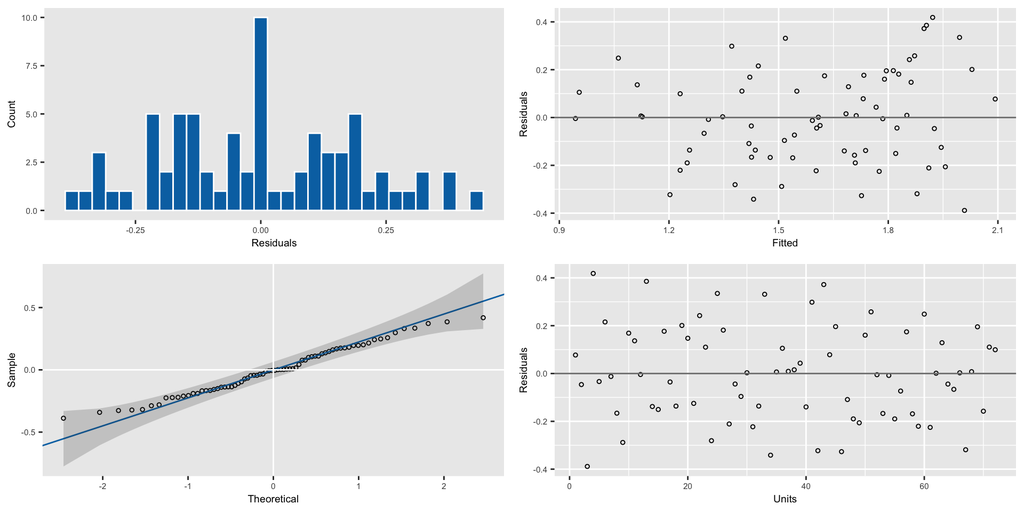

```r
plot(rcbd3)
```

## Dropping the assumtions

```r
rcbd4 <- asreml(
    fixed = Resp ~ b,
    random = ~cv,
    residual = ~ ar1h(cv):id(b),
    data = alfaRCBD
)
```

```
#> ASReml Version 4.2 30/03/2026 10:33:44
#>           LogLik        Sigma2     DF     wall
#>  1      49.59856           1.0     66   10:33:44  (  1 restrained)
#>  2      57.09737           1.0     66   10:33:44  (  1 restrained)
#>  3      61.70343           1.0     66   10:33:44  (  1 restrained)
#>  4      63.34096           1.0     66   10:33:44  (  1 restrained)
#>  5      63.35612           1.0     66   10:33:44  (  1 restrained)
#>  6      63.77299           1.0     66   10:33:44  (  1 restrained)
#>  7      63.44874           1.0     66   10:33:44  (  1 restrained)
#>  8      63.97328           1.0     66   10:33:44
#>  9      63.96703           1.0     66   10:33:44
#> 10      63.63862           1.0     66   10:33:44  (  1 restrained)
#> 11      62.72847           1.0     66   10:33:44
#> 12      63.54572           1.0     66   10:33:44
#> 13      63.95277           1.0     66   10:33:44
```

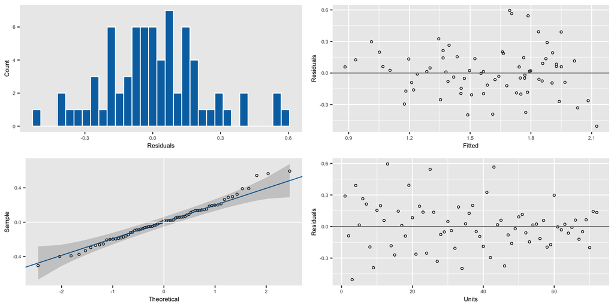

```r
plot(rcbd4)
```

```r
rbind(
    infoCriteria(rcbd1),
    infoCriteria(rcbd2),
    infoCriteria(rcbd3),
    infoCriteria(rcbd4)
)
```

```
#>   fixedDF varDF NBound        AIC        BIC   loglik
#> 1       0     2      0  -99.47393  -95.09462 51.73696
#> 2       0    12      2  -92.32010  -66.04425 58.16005
#> 3       0     3      0 -106.88391 -100.31495 56.44196
#> 4       0    14      1  -99.90553  -69.25037 63.95277
```

## Analysis of a Split-Plot - ASReml

```r
alfaSPLIT <- alfaSPLIT %>%
    arrange(irrigation, cv, block, row, col)

split1 <- asreml(
    fixed = resp ~ irrigation * cv,
    random = ~ block + block:irrigation,
    residual = ~ id(units),
    data = alfaSPLIT
)
```

```
#> ASReml Version 4.2 30/03/2026 10:33:44
#>           LogLik        Sigma2     DF     wall
#>  1      11.59703     0.1189617     48   10:33:44  (  1 restrained)
#>  2      12.45475     0.1160740     48   10:33:44  (  1 restrained)
#>  3      12.72741     0.1127543     48   10:33:44  (  1 restrained)
#>  4      12.83207     0.1099238     48   10:33:44  (  1 restrained)
#>  5      12.83719     0.1092731     48   10:33:44
```

## What if it doesn’t converge?

If the statistical model did not reach convergence, you can try the update function.

```r
split1 <- update.asreml(split1)
```

```
#> ASReml Version 4.2 30/03/2026 10:33:44
#>           LogLik        Sigma2     DF     wall
#>  1      12.83720     0.1092318     48   10:33:44
#>  2      12.83720     0.1092318     48   10:33:44
```

## Variance components

The function `vc()`from the package lucid can extract the variance components from asreml, lme4, mmer, nlme and mcmc.list objects.

```r
lucid::vc(split1)
```

```
#>            effect  component std.error z.ratio bound %ch
#>             block 0.00000017        NA      NA     B  NA
#>  block:irrigation 0.03426      0.03073     1.1     P   0
#>           units!R 0.1092       0.02329     4.7     P   0
```

## Predicted values (you can think of adjusted means)

`Fixed effects: estimates`

- Best linear unbiased estimates (BLUEs)

`Random effects: Predictions`

- Best linear unbiased predictions (BLUPs)

How do we get predicted values (you can think of adjusted means).

```r
preds <- predict(split1, classify = "cv")$pvals
```

```
#> ASReml Version 4.2 30/03/2026 10:33:44
#>           LogLik        Sigma2     DF     wall
#>  1      12.83720     0.1092317     48   10:33:44
#>  2      12.83720     0.1092317     48   10:33:44
#>  3      12.83720     0.1092317     48   10:33:44
```

If you want a tukey test, you can use the library biometryassist

```r
pred.out <- biometryassist::multiple_comparisons(split1, classify = "cv")
```

## Plotting the results

```r
autoplot(pred.out, label_height = 0.5)
```

[figure not shown]

## Repeated Measures

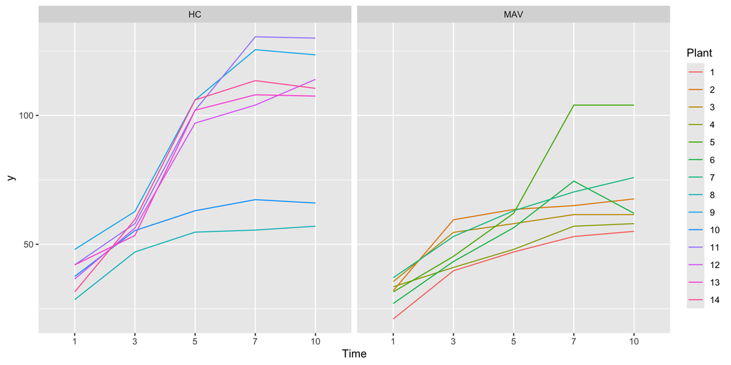

```r
grassUV <- read.csv("grass.csv")

grassUV <- transform(
    grassUV,
    Tmt = factor(Tmt),
    Plant = factor(Plant),
    Time = factor(Time),
    HeightID = factor(HeightID)
)

ggplot(grassUV, aes(x = Time, y = y, group = Plant, colour = Plant)) +
    geom_line() +
    facet_grid(. ~ Tmt)
```

**identity**

```r
id_asreml <- asreml(y ~ Tmt * Time, data = grassUV)
```

```
#> ASReml Version 4.2 30/03/2026 10:33:45
#>           LogLik        Sigma2     DF     wall
#>  1     -209.4418      286.3099     60   10:33:45
```